```python
from scipy.stats import binom, beta
from scipy import integrate
import numpy as np
import matplotlib.pyplot as plt
% matplotlib inline
```

# Bayesian Inference of Mutational Cell Fractions

### Teng Gao, Dominik Glodzik, Nov 2 2018

### Notations

- $\phi$ mutation cell fraction
- $m$ mutation multiplicity
- $b$ number of variant reads
- $d$ sequencing depth or total number of reads
- $c_t$ overall total copy number of the tumor at the mutation locus
- $c_n$ total copy number of the normal at the mutation locus ($c_n = 1$ if mutation on X else 2)
- $\rho$ tumor purity
- $\xi$ variant allele fraction (VAF). Note: This is NOT the observed VAF from sampling reads from the locus, but the true underlying fraction of mutant alleles out of all alleles present in the gene pool

Any bayesian inference has three components: prior, likehood, and a posterior. They are three key components of the Bayes Rule.

$$ p(A|B) = \frac{p(B|A)p(A)}{p(B)}$$

Where $p(A|B)$ is the posterior, $p(B|A)$ the likelihood, and $p(A)$ the prior. $p(B)$ is the normalization factorm, but we often disregard it when our primary goal is optimization. Hence

$$ posterior \propto likelihood \cdot prior$$

In the problem of mutational cell fraction, we first make an inference of the underlying variant allele fraction, then indirectly infer the mutational cell fraction. Bayesian inference allows us to quanfity the uncertainty of the value estimates.

# Likelihood

When we draw reads from the gene pool, we try to get a sense of what the underlying variant allele fraction is. The likelihood of observing $b$ variant reads in $d$ total reads is a binomial distribution where the probability of success is $\xi$:

$$p(b | d, \xi) = Binom(b; d, \xi)$$

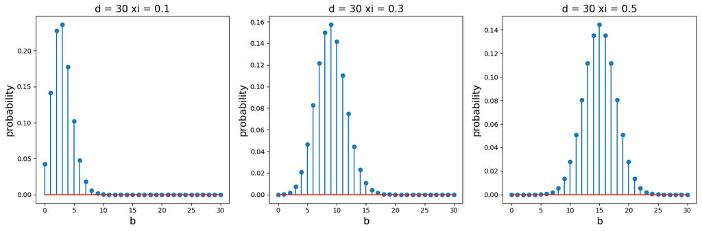

```python
xis = [0.1, 0.3, 0.5]

fig, axes = plt.subplots(1, len(xis), figsize = (5 * len(xis), 5), dpi = 100)

for i, xi in enumerate(xis):
    d = 30
    bs = range(d+1)

    axes[i].stem(bs, [binom.pmf(b, d, xi) for b in bs])
    axes[i].set_xlabel('b', fontsize = 15)
    axes[i].set_ylabel('probability', fontsize = 15)
    axes[i].set_title('d = %s xi = %s' % (d, xi), fontsize = 15)

plt.tight_layout()
```

# Piror

Let's say that we don't have any prior belief for $\xi$ to be any specific value from 0 to 1, so we choose a uniform (beta) prior for $\xi$ with $\alpha = 1$ and $\beta = 1$: $$p(\xi) = Beta(\xi; 1,1)$$

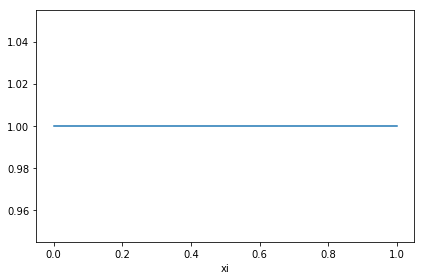

```python
xis = np.linspace(0,1,100)
plt.plot(ps, [beta.pdf(xi, a = 1, b = 1) for xi in xis])
plt.xlabel('xi')
plt.tight_layout()
```

# Posterior

This gives a posterior belief about $\xi$, which follows a Beta distribution:

\begin{align*} p(\xi | b, d) &= \frac{p(b | d, \xi) p(\xi)}{p(b | d)} \\ &= \frac{Binom(b; d, \xi) Beta(\xi; 1,1)}{\int_0^1 Binom(b; d, \xi) d\xi} \\ &= Beta(\xi; b + 1, d - b +1) \\ \end{align*}

This is because the beta distribution is the [conjugate prior](https://en.wikipedia.org/wiki/Conjugate_prior#Table_of_conjugate_distributions) of the binomial distribution. Let's see how different observed VAFs gives different posteriors for $\xi$:

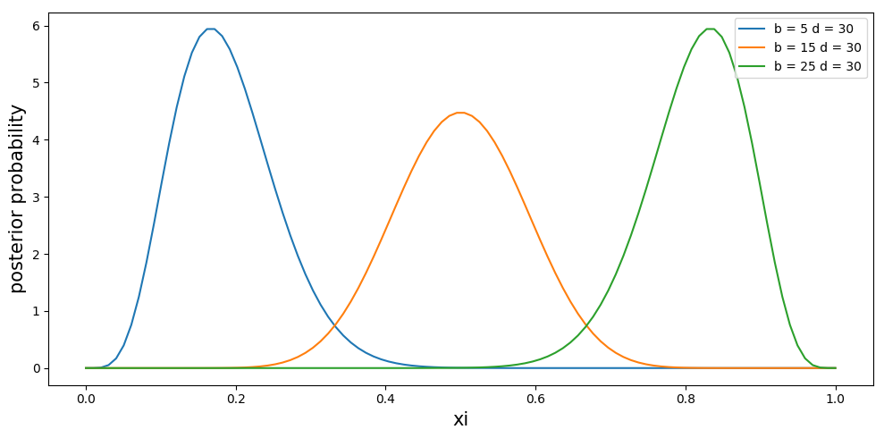

```python
xis = np.linspace(0,1,100)
d = 30
bs = [5, 15, 25]

# fig, axes = plt.subplots(1, len(bs), figsize = (5 * len(bs), 5), dpi = 100)
fig, ax = plt.subplots(1, 1, figsize = (10, 5), dpi = 100)


for i, b in enumerate(bs):
    ax.plot(xis, [beta.pdf(xi, 1 + b, 1 + d - b) for xi in xis], label = 'b = %s d = %s' % (b, d))
ax.set_xlabel('xi', fontsize = 15)
ax.set_ylabel('posterior probability', fontsize = 15)

plt.legend(loc = 1)

plt.tight_layout()
```

Notice that [maximum likelihood](https://stats.stackexchange.com/questions/181035/how-to-derive-the-likelihood-function-for-binomial-distribution-for-parameter-es) of $\xi$ is exactly $\frac{b}{d}$.

# Transformation

Then, we want to infer the value of $\phi$ from the posterior distribution of $\xi$ that we got from the sequencing experiment. We can view $\xi$ as a linear function of $\phi$:

$$\xi \equiv \phi \cdot \frac{\rho \ m}{(1-\rho) \ c_n + \rho \ c_t}$$

Assuming that the other parameters ($\rho, c_n, c_t, m$) are given, $\frac{\rho \ m}{(1-\rho) \ c_n + \rho \ c_t}$ is a constant. Let's denote this constant scaling factor as $C \equiv \frac{\rho \ m}{(1 - \rho) \ c_n + \rho \ c_t}$. Then

$$\xi = C \cdot \phi$$

Then there is a linear map $g$ from $\xi$ to $\phi$:

$$\phi = g(\xi) = \xi \cdot \frac{1}{C}$$

And since we know the posterior distribution of $\xi$, we apply the [Change of Variables Rule](https://en.wikipedia.org/wiki/Probability_density_function#Dependent_variables_and_change_of_variables) to obtain the posterior distribution of $\phi$.

\begin{align*} p(\phi) &= \Bigg|\frac{d}{d\phi} \big( g^{-1} (\phi) \big) \Bigg| \cdot Beta(g^{-1}(\phi); b + 1, d - b + 1) \\ &= \Bigg|\frac{d}{d\phi} \big( C \cdot \phi \big) \Bigg| \cdot Beta(C \cdot \phi; b + 1, d - b + 1) \\ &= C \cdot Beta(C \cdot \phi; b + 1, d - b + 1) \end{align*}

# Properties of $\phi$ posterior

Let's look at how different parameters affect the posterior of $\phi$:

```python
def C(m, rho, c_t, c_n):
    return (rho * m) / ((1-rho)*c_n + rho * c_t)

def posterior_phi(phi, b, d, m, rho, c_t, c_n):
    return C(m, rho, c_t, c_n) * beta.pdf(C(m, rho, c_t, c_n) * phi, b + 1, d - b + 1)

def print_params(params):
    return str(params).strip("{|}").replace("'", "").replace(':', ' =')
```

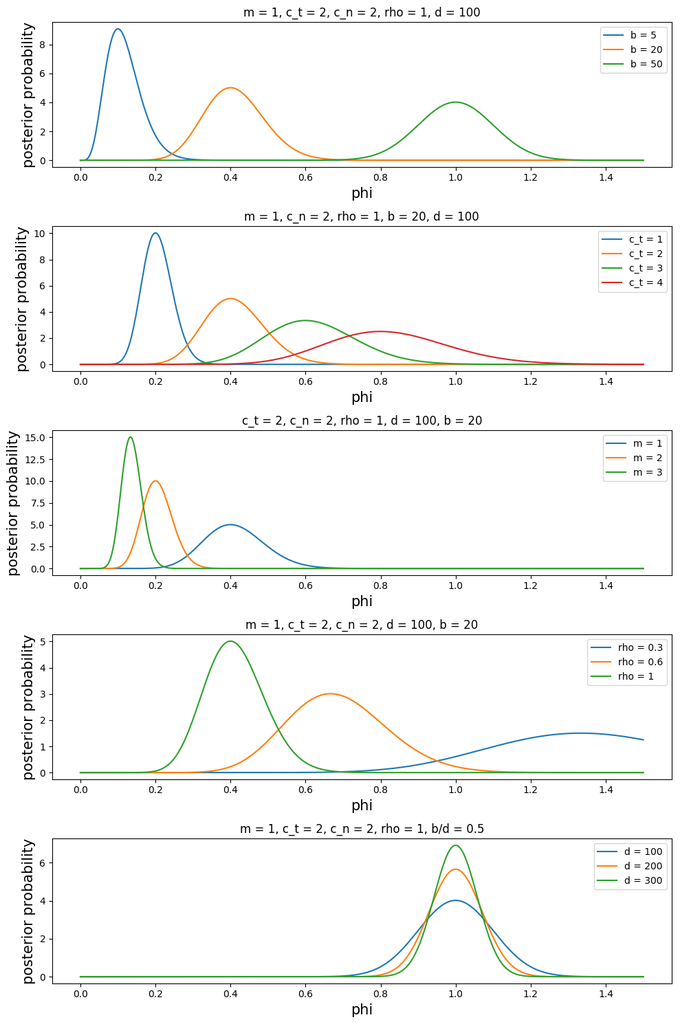

```python
phis = np.linspace(0, 1.5, 500)

fig, axes = plt.subplots(5, 1, figsize = (10, 15), dpi = 100)

# Varying b
params = {'m': 1, 'c_t': 2, 'c_n': 2, 'rho': 1, 'd': 100}

for b in [5, 20, 50]:
    axes[0].plot(phis, [posterior_phi(phi = phi, b = b, **params) for phi in phis],
                 label = 'b = %s' % (b))

axes[0].set_title(print_params(params))

# Varying c_t
params = {'m': 1, 'c_n': 2, 'rho': 1, 'b': 20, 'd': 100}

for c_t in [1,2,3,4]:
    axes[1].plot(phis, [posterior_phi(phi = phi, c_t = c_t, **params) for phi in phis],
                 label = 'c_t = %s' % c_t)

axes[1].set_title(print_params(params))

# Varying m
params = {'c_t': 2, 'c_n': 2, 'rho': 1, 'd': 100, 'b': 20}

for m in [1,2,3]:
    axes[2].plot(phis, [posterior_phi(phi = phi, m = m, **params) for phi in phis],
                 label = 'm = %s' % m)

axes[2].set_title(print_params(params))

# Varying rho
params = {'m': 1, 'c_t': 2, 'c_n': 2, 'd': 100, 'b': 20}

for rho in [0.3, 0.6, 1]:
    axes[3].plot(phis, [posterior_phi(phi = phi, rho = rho, **params) for phi in phis],
                 label = 'rho = %s' % rho)

axes[3].set_title(print_params(params))

# Varying d
params = {'m': 1, 'c_t': 2, 'c_n': 2, 'rho': 1}

for d in [100, 200, 300]:
    b = int(d/2)
    axes[4].plot(phis, [posterior_phi(phi = phi, d = d, b = b, **params) for phi in phis],
                 label = 'd = %s' % d)

axes[4].set_title(print_params(params) + ', b/d = 0.5')

for ax in axes:
    ax.set_xlabel('phi', fontsize = 15)
    ax.set_ylabel('posterior probability', fontsize = 15)
    ax.legend(loc = 1)

plt.tight_layout()
```

# Posterior Sampling

```python
import seaborn as sns
import warnings
warnings.filterwarnings("ignore")
```

```python
def sample_phi(b, d, m, c_t, c_n, rho, size = 1000):
    samples = beta.rvs(1 + b, 1 + d - b, size = size) / C(m, rho, c_t, c_n)
    return samples
```

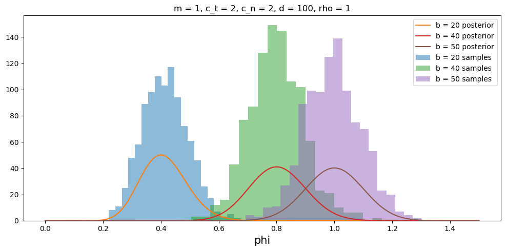

```python
fig, ax = plt.subplots(1, 1, figsize = (10, 5), dpi = 100)
phis = np.linspace(0, 1.5, 500)
params = {'m': 1, 'c_t': 2, 'c_n': 2, 'd': 100, 'rho': 1}

for b in [20, 40, 50]:
    ax.hist(sample_phi(b = b, **params, size = 1000), bins = 20, alpha = 0.5, label = 'b = %s samples' % b)
    ax.plot(phis, [posterior_phi(b = b, phi = phi, **params) * 10 for phi in phis], label = 'b = %s posterior' % b)

ax.set_xlabel('phi', fontsize = 15)
ax.legend()
ax.set_title(print_params(params))
plt.tight_layout()
```

# A Note about Point Estimate of $\phi$

If we just want a single point estimate for $\phi$, namely the conditional expectation of $\phi$ given the observed variables

$$\hat{\phi} = E(\phi | m, b, d, c_t, c_n, \rho) = \int \phi \ p(\phi | m, b, d, c_t, c_n, \rho) \ d\phi$$

we can apply the [Law of the Unconscious Statistician](https://en.wikipedia.org/wiki/Law_of_the_unconscious_statistician)

\begin{align} E(\phi | m, b, d, c_t, c_n, \rho) &= \int \phi \ p(\phi | m, b, d, c_t, c_n, \rho) \ d\phi \\ &= \int g(\xi) p(\xi | m, b, d, c_t, c_n, \rho) \ d \xi \\ &= \int g(\xi) p(\xi | b, d) \ d \xi \\ &= \int \frac{1}{C} \ \xi \ p(\xi | b, d) \ d \xi \\ &= \frac{1}{C} \int \xi \ p(\xi | b, d) \ d \xi \\ &= \frac{1}{C} E(\xi| b, d) \\ &= \frac{1}{C} \frac{b}{d} \end{align}

Expand $C$ and we get

$$ \hat{\phi} = \frac{1}{m} \cdot \frac{b}{d} \cdot \frac{(1-\rho) \ c_n + \rho \ c_t}{\rho} $$

Which is exactly Eq. 4 in [Principles of reconstructing the subclonal archeitecture of cancers](https://ora.ox.ac.uk/objects/uuid:ea40d5b1-a4f8-447e-9e5a-4c09ae9a0e2a/download_file?file_format=pdf&safe_filename=Dentro%2Bet%2Bal.%2BAAM.pdf&type_of_work=Journal+article)!